# Week 3 HW

# Problem 15 Step 1 (inset picture) and step 2

# Step 2. Write your answer below.

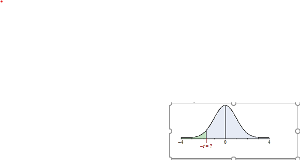

```
I choose the 2nd picture because the value of t should be on the left as per the question. Also t = -1.7 which would be on the left represented by the green shaded area.
```

Problem 16: The following measurements ( in picocuries per liter ) were recorded by a set of helium gas detectors installed in a laboratory facility:  
383.6, 347.1, 371.9, 347.6, 325.8, 337 Using these measurements, construct a 90% confidence interval for the mean level of helium gas present in the facility. Assume the population is normally distributed.

```
Step 1. Calculate the sample mean for the given sample data. (Round answer to 2 decimal places)
Step 2. Calculate the sample standard deviation for the given sample data. (Round answer to 2 decimal places)
Step 3. Find the critical value that should be used in constructing the confidence interval. (Round answer to 3 decimal places)
Step 4. Construct the 90% confidence interval. (Round answer to 2 decimal places

    Lower Bound:
    Upper Bound:
```

```python
#Problem 16
data = (383.6,347.1,371.9,347.6,325.8,337)
mymean = np.mean(data)
mysd = np.std(data,ddof=1)
tvalue = t.ppf(.95,5)
lower = mymean-tvalue*mysd/6**.5
upper = mymean+tvalue*mysd/6**.5
print(lower,",",upper)
```

```
334.33524059559835 , 369.998092737735
```

**Problem 17: A random sample of 16 fields of spring wheat has a mean yield of 46.4 bushels per acre and standard deviation of 2.45 bushels per acre. Determine the 80% confidence interval for the true mean yield. Assume the population is normally distributed.**

```
Step 1. Find the critical value that should be used in constructing the confidence interval. (Round answer to 3 decimal places)
Step 2. Construct the 80% confidence interval. (Round answer to 1 decimal place)
Lower bound:
Upper bound:
```

```python
#Problem 17 step 1
norm.ppf(0.9)# 80% confidence level
```

```
1.2815515655446004
```

```python
#Problem 17 Step 2
print(norm.ppf(.1,46.4, 2.45/np.sqrt(16)),norm.ppf(.9,3.9, 2.45/np.sqrt(208)))
```

```
45.61504966610393 4.117706052119604
```

**Problem 18: A toy manufacturer wants to know how many new toys children buy each year. She thinks the mean is 8 toys per year. Assume a previous study found the standard deviation to be 1.9. How large of a sample would be required in order to estimate the mean number of toys bought per child at the 99% confidence level with an error of at most 0.13 toys? (Round your answer up to the next integer).**

# Problem 18

99% z = 2.576

**Problem 19: A research scientist wants to know how many times per hour a certain strand of bacteria reproduces. He believes that the mean is 12.6. Assume the variance is known to be 3.61. How large of a sample would be required in order to estimate the mean number of reproductions per hour at the 95% confidence level with an error of at most 0.19 reproductions? (Round your answer up to the next integer)**

```python
#Problem 19 not sure

print(norm.ppf(.025,12.6,1.9/np.sqrt(7472)),norm.ppf(.97,12.6,1.9/np.sqrt(7472)))
```

[output not shown]

**Problem 20: The state education commission wants to estimate the fraction of tenth grade students that have reading skills at or below the eighth grade level.**

Step 1. Suppose a sample of 2089 tenth graders is drawn. Of the students sampled, 1734 read above the eighth grade level. Using the data, estimate the proportion of tenth graders reading at or below the eighth grade level. (Write your answer as a fraction or a decimal number rounded to 3 decimal places)

Step 2. Suppose a sample of 2089 tenth graders is drawn. Of the students sampled, 1734 read above the eighth grade level. Using the data, construct the 98% confidence interval for the population proportion of tenth graders reading at or below the eighth grade level. (Round your answers to 3 decimal places) Lower bound: Upper bound:

```python
#Problem 20
```

**Problem 21 An environmentalist wants to find out the fraction of oil tankers that have spills each month. Step 1. Suppose a sample of 474 tankers is drawn. Of these ships, 156 had spills. Using the data, estimate the proportion of oil tankers that had spills. (Write your answer as a fraction or a decimal number rounded to 3 decimal places)**

```python
##Problem 21

samplesize = 474
spills = 156

Proportionspilled  = spills/samplesize
print(Proportionspilled)
```

```
0.3291139240506329
```